# Clean-Up Week 3

# **회귀분석팀 클린업 3주차 R 예제**

2주차에서 썻던 데이터 가져와서 하자!

```r
library(data.table)
library(tidyverse)
data = fread('2017-18_NBA_salary.csv')
```

데이터 확인

```r
data %>% dim
```

```
## [1] 485  28
```

```r
data %>% glimpse
```

```
## Rows: 485
## Columns: 28
## $ Player          <chr> "Zhou Qi", "Zaza Pachulia", "Zach Randolph", "Zach ...
## $ Salary          <int> 815615, 3477600, 12307692, 3202217, 3057240, 131261...
## $ NBA_Country     <chr> "China", "Georgia", "USA", "USA", "USA", "USA", "US...
## $ NBA_DraftNumber <int> 43, 42, 19, 13, 10, 62, 62, 62, 23, 35, 62, 6, 40, ...
## $ Age             <int> 22, 33, 36, 22, 20, 24, 30, 23, 30, 23, 27, 24, 27,...
## $ Tm              <chr> "HOU", "GSW", "SAC", "CHI", "POR", "DAL", "BOS", "M...
## $ G               <int> 16, 66, 59, 24, 62, 79, 2, 5, 70, 45, 42, 70, 77, 6...
## $ MP              <int> 87, 937, 1508, 656, 979, 2238, 7, 118, 2200, 430, 4...
## $ PER             <dbl> 0.6, 16.8, 17.3, 14.6, 8.2, 11.5, -4.9, 0.9, 11.1, ...
## $ `TS%`           <dbl> 0.303, 0.608, 0.529, 0.499, 0.487, 0.543, 0.000, 0....
## $ `3PAr`          <dbl> 0.593, 0.004, 0.193, 0.346, 0.387, 0.489, 0.667, 0....
## $ FTr             <dbl> 0.370, 0.337, 0.140, 0.301, 0.146, 0.141, 0.000, 0....
## $ `ORB%`          <dbl> 6.5, 11.0, 7.0, 1.4, 4.9, 1.3, 15.9, 0.0, 5.0, 13.6...
## $ `DRB%`          <dbl> 16.8, 25.0, 23.8, 14.4, 18.3, 11.3, 15.4, 5.0, 14.0...
## $ `TRB%`          <dbl> 11.7, 18.5, 15.0, 7.7, 11.7, 6.1, 15.7, 2.5, 9.5, 1...
## $ `AST%`          <dbl> 1.5, 15.4, 14.9, 18.6, 7.3, 13.3, 0.0, 23.2, 9.7, 1...
## $ `STL%`          <dbl> 1.1, 1.9, 1.4, 1.8, 0.8, 1.4, 7.2, 2.6, 0.9, 1.8, 1...
## $ `BLK%`          <dbl> 6.8, 1.3, 0.6, 0.5, 2.5, 0.3, 0.0, 2.4, 1.4, 2.8, 4...
## $ `TOV%`          <dbl> 18.2, 19.3, 12.5, 9.7, 15.6, 9.1, 0.0, 19.3, 12.0, ...
## $ `USG%`          <dbl> 19.5, 17.2, 27.6, 29.5, 15.5, 17.0, 19.2, 21.7, 14....
## $ OWS             <dbl> -0.4, 1.7, 0.3, -0.1, -0.4, 1.6, -0.1, -0.5, 2.0, 0...
## $ DWS             <dbl> 0.1, 1.4, 1.1, 0.5, 1.2, 1.6, 0.0, 0.1, 1.0, 0.6, 0...
## $ WS              <dbl> -0.2, 3.1, 1.4, 0.4, 0.8, 3.1, 0.0, -0.4, 3.1, 1.4,...
## $ `WS/48`         <dbl> -0.121, 0.160, 0.046, 0.027, 0.038, 0.067, -0.251, ...
## $ OBPM            <dbl> -10.6, -0.6, -0.6, -0.7, -3.7, -0.4, -12.6, -8.7, -...
## $ DBPM            <dbl> 0.5, 1.3, -1.3, -2.0, 0.9, -0.5, -0.7, -1.9, -0.6, ...
## $ BPM             <dbl> -10.1, 0.8, -1.9, -2.6, -2.9, -0.9, -13.3, -10.6, -...
## $ VORP            <dbl> -0.2, 0.7, 0.0, -0.1, -0.2, 0.6, 0.0, -0.3, 0.5, 0....
```

```r
data <- data[complete.cases(data), ] # 결측치 제거
data <- data[-c(223:224), ] #겹치는 선수 삭제
data$Player <- NULL
data$Tm <- NULL
data$NBA_Country <- NULL

data = data %>% select('Salary', 'NBA_DraftNumber', 'Age', 'MP', 'PER',
                       `TS%`, `DRB%`, VORP, G, OBPM, DBPM, BPM, OWS, DWS, WS, `AST%`, `STL%`)
```

원래 중요하다고 나온 변수들에 일종의 노이즈를 좀 주었습니다! 안중요하다고 모델이 말한 변수들도 넣어서 만듬!

또한 PCR을 위해 범주형 변수 삭제함

```r
# train test split 진행
set.seed(1234)
train_idx <- caret::createDataPartition(data$Salary, p = .8, list = FALSE, times = 1)
train = data[train_idx, ]
test = data[-train_idx, ]

train$Salary = train$Salary^0.22
test$Salary = test$Salary^0.22
# 단위수정및 분포형태 고려

train_x = train %>% select(-Salary) %>% as.matrix()
train_y = train %>% select(Salary) %>% unlist %>% as.vector
test_x = test %>% select(-Salary) %>% as.matrix()
test_y = test %>% select(Salary) %>% unlist() %>% as.vector()

dim(train) # 387행 17열
```

```
## [1] 387  17
```

```r
dim(test) # 94행 17열
```

```
## [1] 94 17
```

관측치에 비해 변수가 어느정도 있는 형태이다. 따라서 다중공선성이 의심된다.

```r
lm_fit = lm(Salary ~ ., data = train)
lm_fit %>% summary
```

```
##
## Call:
## lm(formula = Salary ~ ., data = train)
##
## Residuals:
##      Min       1Q   Median       3Q      Max
## -17.9163  -3.3874   0.1565   3.4507  16.7297
##
## Coefficients:
##                  Estimate Std. Error t value Pr(>|t|)
## (Intercept)     10.250686   4.055036   2.528   0.0119 *
## NBA_DraftNumber -0.118414   0.014769  -8.018 1.43e-14 ***
## Age              0.567076   0.070565   8.036 1.26e-14 ***
## MP               0.005455   0.001079   5.053 6.84e-07 ***
## PER             -0.092107   0.112273  -0.820   0.4125
## `TS%`            3.933143   4.832146   0.814   0.4162
## `DRB%`           0.091750   0.072788   1.261   0.2083
## VORP             0.146847   0.736506   0.199   0.8421
## G               -0.051224   0.028965  -1.768   0.0778 .
## OBPM             0.679095   5.863210   0.116   0.9079
## DBPM             0.773287   5.853663   0.132   0.8950
## BPM             -0.602774   5.857064  -0.103   0.9181
## OWS              1.265847   5.422231   0.233   0.8155
## DWS              1.144759   5.406476   0.212   0.8324
## WS              -1.067746   5.435267  -0.196   0.8444
## `AST%`           0.039058   0.037880   1.031   0.3032
## `STL%`          -0.168906   0.388210  -0.435   0.6638
## ---
## Signif. codes:  0 '***' 0.001 '**' 0.01 '*' 0.05 '.' 0.1 ' ' 1
##
## Residual standard error: 5.491 on 370 degrees of freedom
## Multiple R-squared:  0.5847, Adjusted R-squared:  0.5668
## F-statistic: 32.56 on 16 and 370 DF,  p-value: < 2.2e-16
```

회귀식에서 유의하지 않은 변수들이 많다. 다중공선성이 있는지를 확인해보자

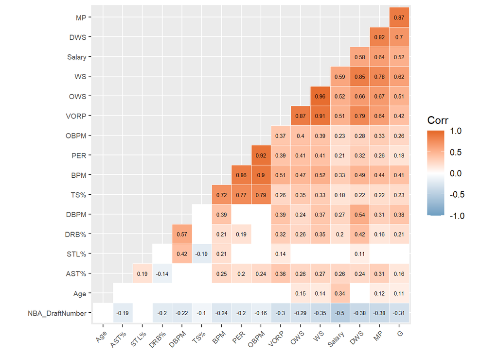

```r
library(ggcorrplot)
corr <- cor(train) # 상관계수 행렬
p_mat <- cor_pmat(train) # 상관계수 p-value 행렬
ggcorrplot(corr, hc.order = T, type = "lower",
           outline.color = "white", ggtheme = ggplot2::theme_gray(),
           colors = c("#6D9EC1", "white", "#E46726"), lab = T, p.mat = p_mat,
           insig = "blank", lab_size = 2, tl.cex = 7)
```

상관계수가 높은 친구들이 많이 보인다.

```r
car::vif(lm_fit)
```

```
## NBA_DraftNumber             Age              MP             PER           `TS%`
##        1.243086        1.075528        9.817435       13.261045        3.609107
##          `DRB%`            VORP               G            OBPM            DBPM
##        3.194818       11.097507        6.531067    11913.872140     2539.575935
##             BPM             OWS             DWS              WS          `AST%`
##    13934.743425     1407.697044      425.216202     2887.329251        1.481536
##          `STL%`
##        2.023076
```

Vif 값이 상당히 높다. 단순히 무시할 수준이 아님을 짐작 가능하다!

### 1. 변수 선택법

변수선택법은 cv와 같은 방법을 사용하지 않고, 그냥 주어진 train을 한번에 활용해서 결론을 내는 방식을 주로 사용한다.

##### Best Subset Selection

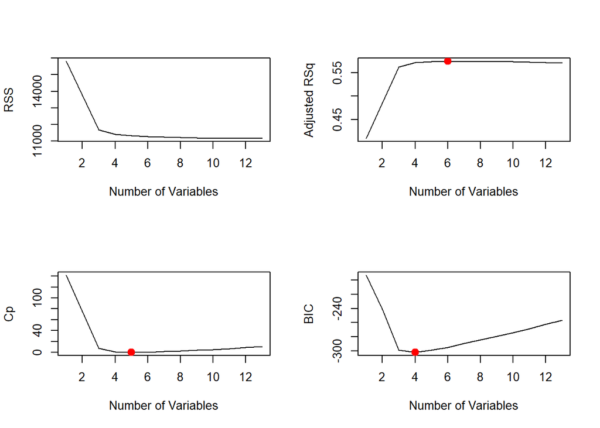

```r
library(leaps)
best_subset = regsubsets(Salary ~ ., data = train, nvmax = 13)
bs = best_subset %>% summary

par(mfrow = c(2, 2))
plot(bs$rss, xlab = "Number of Variables", ylab = "RSS", type = "l")
plot(bs$adjr2, xlab = "Number of Variables", ylab = "Adjusted RSq", type = "l")
l = which.max(bs$adjr2)
points(l, bs$adjr2[l], col = "red", cex = 2, pch = 20)
plot(bs$cp, xlab = "Number of Variables", ylab = "Cp", type = 'l')
l = which.min(bs$cp)
points(l, bs$cp[l], col = "red", cex = 2, pch = 20)
plot(bs$bic, xlab = "Number of Variables", ylab = "BIC", type = 'l')
l = which.min(bs$bic)
points(l, bs$bic[l], col = "red", cex = 2, pch = 20)
```

```r
par(mfrow = c(1, 1))
```

```r
coef(best_subset, 5)
```

```
##     (Intercept) NBA_DraftNumber             Age              MP          `DRB%`
##    10.081621663    -0.119548095     0.578303269     0.004232471     0.070575229
##            VORP
##     0.725333898
```

```r
best_lm_fit = lm(Salary ~ NBA_DraftNumber + Age + MP + VORP + G, data = train)
```

##### Forward Selection

```r
forward_selection = regsubsets(Salary ~ ., data = train, nvmax = 13, method = "forward")
summary(forward_selection)
```

```
## Subset selection object
## Call: regsubsets.formula(Salary ~ ., data = train, nvmax = 13, method = "forward")
## 16 Variables  (and intercept)
##                 Forced in Forced out
## NBA_DraftNumber     FALSE      FALSE
## Age                 FALSE      FALSE
## MP                  FALSE      FALSE
## PER                 FALSE      FALSE
## `TS%`               FALSE      FALSE
## `DRB%`              FALSE      FALSE
## VORP                FALSE      FALSE
## G                   FALSE      FALSE
## OBPM                FALSE      FALSE
## DBPM                FALSE      FALSE
## BPM                 FALSE      FALSE
## OWS                 FALSE      FALSE
## DWS                 FALSE      FALSE
## WS                  FALSE      FALSE
## `AST%`              FALSE      FALSE
## `STL%`              FALSE      FALSE
## 1 subsets of each size up to 13
## Selection Algorithm: forward
##           NBA_DraftNumber Age MP  PER `TS%` `DRB%` VORP G   OBPM DBPM BPM OWS
## 1  ( 1 )  " "             " " "*" " " " "   " "    " "  " " " "  " "  " " " "
## 2  ( 1 )  "*"             " " "*" " " " "   " "    " "  " " " "  " "  " " " "
## 3  ( 1 )  "*"             "*" "*" " " " "   " "    " "  " " " "  " "  " " " "
## 4  ( 1 )  "*"             "*" "*" " " " "   " "    "*"  " " " "  " "  " " " "
## 5  ( 1 )  "*"             "*" "*" " " " "   "*"    "*"  " " " "  " "  " " " "
## 6  ( 1 )  "*"             "*" "*" " " " "   "*"    "*"  "*" " "  " "  " " " "
## 7  ( 1 )  "*"             "*" "*" " " " "   "*"    "*"  "*" " "  " "  " " " "
## 8  ( 1 )  "*"             "*" "*" " " " "   "*"    "*"  "*" " "  "*"  " " " "
## 9  ( 1 )  "*"             "*" "*" " " " "   "*"    "*"  "*" " "  "*"  " " " "
## 10  ( 1 ) "*"             "*" "*" " " " "   "*"    "*"  "*" " "  "*"  " " "*"
## 11  ( 1 ) "*"             "*" "*" " " "*"   "*"    "*"  "*" " "  "*"  " " "*"
## 12  ( 1 ) "*"             "*" "*" "*" "*"   "*"    "*"  "*" " "  "*"  " " "*"
## 13  ( 1 ) "*"             "*" "*" "*" "*"   "*"    "*"  "*" "*"  "*"  " " "*"
##           DWS WS  `AST%` `STL%`
## 1  ( 1 )  " " " " " "    " "
## 2  ( 1 )  " " " " " "    " "
## 3  ( 1 )  " " " " " "    " "
## 4  ( 1 )  " " " " " "    " "
## 5  ( 1 )  " " " " " "    " "
## 6  ( 1 )  " " " " " "    " "
## 7  ( 1 )  " " " " "*"    " "
## 8  ( 1 )  " " " " "*"    " "
## 9  ( 1 )  " " " " "*"    "*"
## 10  ( 1 ) " " " " "*"    "*"
## 11  ( 1 ) " " " " "*"    "*"
## 12  ( 1 ) " " " " "*"    "*"
## 13  ( 1 ) " " " " "*"    "*"
```

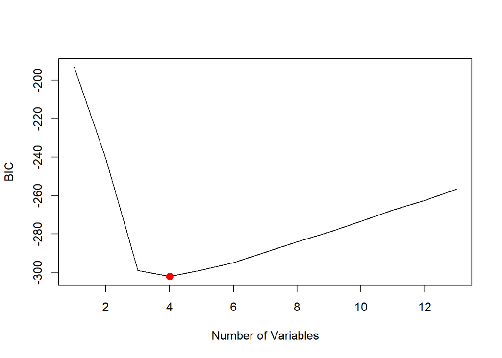

```r
fs = summary(forward_selection)
plot(fs$bic, xlab = "Number of Variables", ylab = "BIC", type = 'l')
l = which.min(fs$bic)
points(l, fs$bic[l], col = "red", cex = 2, pch = 20)
```

```r
coef(forward_selection, 5)
```

```
##     (Intercept) NBA_DraftNumber             Age              MP          `DRB%`
##    10.081621663    -0.119548095     0.578303269     0.004232471     0.070575229
##            VORP
##     0.725333898
```

```r
backward_selection = regsubsets(Salary ~ ., data = train, nvmax = 13, method = "forward")
summary(backward_selection)
```

```
## Subset selection object
## Call: regsubsets.formula(Salary ~ ., data = train, nvmax = 13, method = "forward")
## 16 Variables  (and intercept)
##                 Forced in Forced out
## NBA_DraftNumber     FALSE      FALSE
## Age                 FALSE      FALSE
## MP                  FALSE      FALSE
## PER                 FALSE      FALSE
## `TS%`               FALSE      FALSE
## `DRB%`              FALSE      FALSE
## VORP                FALSE      FALSE
## G                   FALSE      FALSE
## OBPM                FALSE      FALSE
## DBPM                FALSE      FALSE
## BPM                 FALSE      FALSE
## OWS                 FALSE      FALSE
## DWS                 FALSE      FALSE
## WS                  FALSE      FALSE
## `AST%`              FALSE      FALSE
## `STL%`              FALSE      FALSE
## 1 subsets of each size up to 13
## Selection Algorithm: forward
##           NBA_DraftNumber Age MP  PER `TS%` `DRB%` VORP G   OBPM DBPM BPM OWS
## 1  ( 1 )  " "             " " "*" " " " "   " "    " "  " " " "  " "  " " " "
## 2  ( 1 )  "*"             " " "*" " " " "   " "    " "  " " " "  " "  " " " "
## 3  ( 1 )  "*"             "*" "*" " " " "   " "    " "  " " " "  " "  " " " "
## 4  ( 1 )  "*"             "*" "*" " " " "   " "    "*"  " " " "  " "  " " " "
## 5  ( 1 )  "*"             "*" "*" " " " "   "*"    "*"  " " " "  " "  " " " "
## 6  ( 1 )  "*"             "*" "*" " " " "   "*"    "*"  "*" " "  " "  " " " "
## 7  ( 1 )  "*"             "*" "*" " " " "   "*"    "*"  "*" " "  " "  " " " "
## 8  ( 1 )  "*"             "*" "*" " " " "   "*"    "*"  "*" " "  "*"  " " " "
## 9  ( 1 )  "*"             "*" "*" " " " "   "*"    "*"  "*" " "  "*"  " " " "
## 10  ( 1 ) "*"             "*" "*" " " " "   "*"    "*"  "*" " "  "*"  " " "*"
## 11  ( 1 ) "*"             "*" "*" " " "*"   "*"    "*"  "*" " "  "*"  " " "*"
## 12  ( 1 ) "*"             "*" "*" "*" "*"   "*"    "*"  "*" " "  "*"  " " "*"
## 13  ( 1 ) "*"             "*" "*" "*" "*"   "*"    "*"  "*" "*"  "*"  " " "*"
##           DWS WS  `AST%` `STL%`
## 1  ( 1 )  " " " " " "    " "
## 2  ( 1 )  " " " " " "    " "
## 3  ( 1 )  " " " " " "    " "
## 4  ( 1 )  " " " " " "    " "
## 5  ( 1 )  " " " " " "    " "
## 6  ( 1 )  " " " " " "    " "
## 7  ( 1 )  " " " " "*"    " "
## 8  ( 1 )  " " " " "*"    " "
## 9  ( 1 )  " " " " "*"    "*"
## 10  ( 1 ) " " " " "*"    "*"
## 11  ( 1 ) " " " " "*"    "*"
## 12  ( 1 ) " " " " "*"    "*"
## 13  ( 1 ) " " " " "*"    "*"
```

```r
coef(backward_selection, 5)
```

```
##     (Intercept) NBA_DraftNumber             Age              MP          `DRB%`
##    10.081621663    -0.119548095     0.578303269     0.004232471     0.070575229
##            VORP
##     0.725333898
```

### Principal Component Regression

PCR에서는 주성분의 갯수를 튜닝해줘야 한다. 원래는 뒤의 릿지 라쏘처럼 CV하는게 좋지만….코드짜기 간단한 holdout으로 갈게요 ㅎㅎ

```r
set.seed(1234)
train_idx <- caret::createDataPartition(train$Salary, p = .8, list = FALSE, times = 1)

train_tune = data[train_idx, ]
val = data[-train_idx, ]
```

튜닝을 위한 셋과 validation set을 나눈다.

```r
library(pls)
library(MLmetrics)
pcr_fit = pcr(Salary ~ ., data = train_tune, scale = TRUE)
pcr_fit %>% summary
```

```
## Data:    X dimension: 311 16
##  Y dimension: 311 1
## Fit method: svdpc
## Number of components considered: 16
## TRAINING: % variance explained
##         1 comps  2 comps  3 comps  4 comps  5 comps  6 comps  7 comps  8 comps
## X         40.43    56.24    65.33    73.81    79.99    85.63    90.32    94.30
## Salary    31.37    35.46    40.19    40.20    42.52    43.45    48.66    49.93
##         9 comps  10 comps  11 comps  12 comps  13 comps  14 comps  15 comps
## X         96.15     97.61     98.89     99.38     99.75    100.00    100.00
## Salary    50.47     50.65     50.79     50.86     54.48     54.55     54.61
##         16 comps
## X         100.00
## Salary     54.75
```

```r
rmse_pcr_df = data.frame(rep(NA, 16), rep(NA, 16))
colnames(rmse_pcr_df) = c('PC', 'RMSE')
rmse_pcr_df %>% head
```

```
##   PC RMSE
## 1 NA   NA
## 2 NA   NA
## 3 NA   NA
## 4 NA   NA
## 5 NA   NA
## 6 NA   NA
```

```r
for (i in 1:dim(rmse_pcr_df)[1]) {
  pcr_fit = pcr(Salary ~ ., data = train_tune)
  pred_y = predict(pcr_fit, val, ncomp = i)
  rmse_pcr_df[i, 2] = RMSE(pred_y, val$Salary)
  rmse_pcr_df[i, 1] = paste('PC', i)
}

rmse_pcr_df
```

```
##       PC    RMSE
## 1   PC 1 7088567
## 2   PC 2 6837246
## 3   PC 3 6355998
## 4   PC 4 6408119
## 5   PC 5 6426802
## 6   PC 6 6344040
## 7   PC 7 5663611
## 8   PC 8 5649619
## 9   PC 9 5539765
## 10 PC 10 5524919
## 11 PC 11 5523358
## 12 PC 12 5522745
## 13 PC 13 5516355
## 14 PC 14 5515748
## 15 PC 15 5532336
## 16 PC 16 5539273
```

이렇게 돌렸습니다.

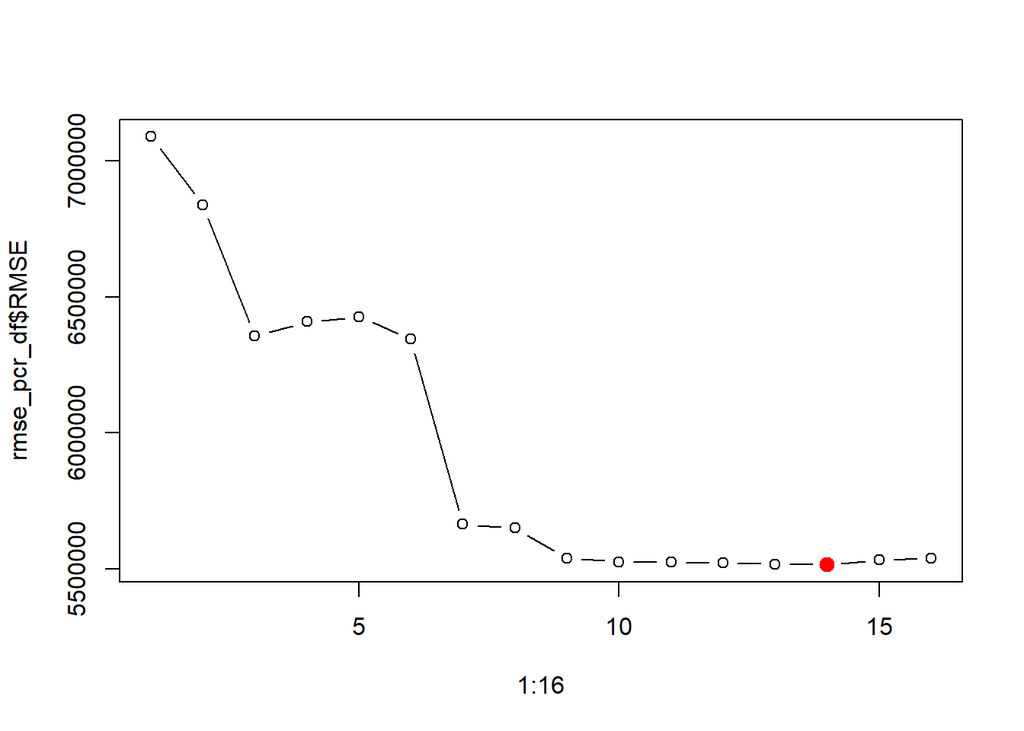

```r
plot(1:16, rmse_pcr_df$RMSE, type = 'b')
l = which.min(rmse_pcr_df$RMSE)
points(l, rmse_pcr_df$RMSE[l], col = "red", cex = 2, pch = 20)
```

```r
pcr_fit = pcr(Salary ~ ., data = train, ncomp = 10)
pcr_fit %>% summary
```

```
## Data:    X dimension: 387 16
##  Y dimension: 387 1
## Fit method: svdpc
## Number of components considered: 10
## TRAINING: % variance explained
##         1 comps  2 comps  3 comps  4 comps  5 comps  6 comps  7 comps  8 comps
## X         99.88    99.94    99.96    99.98    99.99    100.0   100.00   100.00
## Salary    41.12    48.91    49.16    49.17    49.18     49.6    58.13    58.22
##         9 comps  10 comps
## X         100.0    100.00
## Salary     58.3     58.33
```

pcr_fit을 좀있다가 비교해보자!

### ridge regression

```r
library(glmnet)
# if alpha=0 -> ridge; if alpha=1 -> lasso.
# Default: standardize = TRUE
```

ridge 가볼까?

```r
grid_lambda = seq(from = 0, to = 10, length.out = 200)
grid_lambda
```

```
##   [1]  0.00000000  0.05025126  0.10050251  0.15075377  0.20100503  0.25125628
##   [7]  0.30150754  0.35175879  0.40201005  0.45226131  0.50251256  0.55276382
##  [13]  0.60301508  0.65326633  0.70351759  0.75376884  0.80402010  0.85427136
##  [19]  0.90452261  0.95477387  1.00502513  1.05527638  1.10552764  1.15577889
##  [25]  1.20603015  1.25628141  1.30653266  1.35678392  1.40703518  1.45728643
##  [31]  1.50753769  1.55778894  1.60804020  1.65829146  1.70854271  1.75879397
##  [37]  1.80904523  1.85929648  1.90954774  1.95979899  2.01005025  2.06030151
##  [43]  2.11055276  2.16080402  2.21105528  2.26130653  2.31155779  2.36180905
##  [49]  2.41206030  2.46231156  2.51256281  2.56281407  2.61306533  2.66331658
##  [55]  2.71356784  2.76381910  2.81407035  2.86432161  2.91457286  2.96482412
##  [61]  3.01507538  3.06532663  3.11557789  3.16582915  3.21608040  3.26633166
##  [67]  3.31658291  3.36683417  3.41708543  3.46733668  3.51758794  3.56783920
##  [73]  3.61809045  3.66834171  3.71859296  3.76884422  3.81909548  3.86934673
##  [79]  3.91959799  3.96984925  4.02010050  4.07035176  4.12060302  4.17085427
##  [85]  4.22110553  4.27135678  4.32160804  4.37185930  4.42211055  4.47236181
```

[output cut: 19 more lines]

```r
cv_ridge_fit = cv.glmnet(x = train_x, y = train_y, alpha = 0, lambda = grid_lambda, nfolds = 5)
opt_ridge_lambda = cv_ridge_fit$lambda.min ; opt_ridge_lambda
```

```
## [1] 0.7537688
```

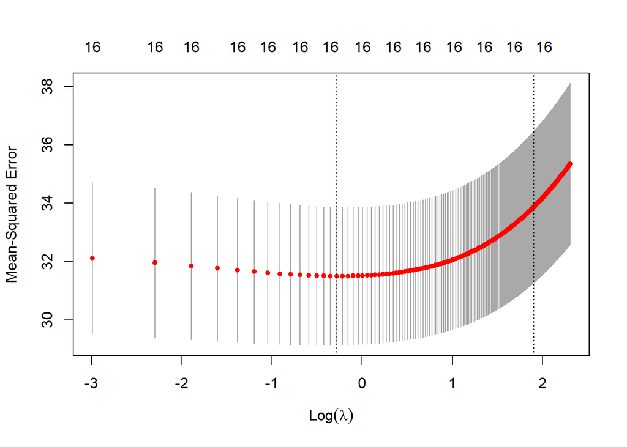

```r
cv_ridge_fit %>% plot
```

```r
cv_ridge_fit %>% coef
```

```
## 17 x 1 sparse Matrix of class "dgCMatrix"
##                            1
## (Intercept)     16.169741233
## NBA_DraftNumber -0.068510716
## Age              0.316895753
## MP               0.001468371
## PER             -0.009566327
## TS%              0.423508911
## DRB%             0.023551653
## VORP             0.361742042
## G                0.026402076
## OBPM             0.011318989
## DBPM             0.080193076
## BPM              0.024207064
## OWS              0.250554548
## DWS              0.648906468
## WS               0.218521050
## AST%             0.044169967
## STL%            -0.123132290
```

0인 계수가 없다!!!

```r
ridge_fit = glmnet(x = train_x, y = train_y, alpha = 0, lambda = opt_ridge_lambda)
ridge_fit %>% coef
```

```
## 17 x 1 sparse Matrix of class "dgCMatrix"
##                            s0
## (Intercept)     11.3768588170
## NBA_DraftNumber -0.1102884026
## Age              0.5205764875
## MP               0.0031416593
## PER             -0.0463592176
## TS%              1.7970650558
## DRB%             0.0500332252
## VORP             0.2724025734
## G               -0.0002085056
## OBPM             0.0110683182
## DBPM             0.0697226409
## BPM              0.0226327387
## OWS              0.1617579297
## DWS              0.4829559826
## WS               0.1541611302
## AST%             0.0474665969
## STL%            -0.1582602764
```

### Lasso regression

```r
grid_lambda = seq(from = 0, to = 10, length.out = 200)
grid_lambda
```

```
##   [1]  0.00000000  0.05025126  0.10050251  0.15075377  0.20100503  0.25125628
##   [7]  0.30150754  0.35175879  0.40201005  0.45226131  0.50251256  0.55276382
##  [13]  0.60301508  0.65326633  0.70351759  0.75376884  0.80402010  0.85427136
##  [19]  0.90452261  0.95477387  1.00502513  1.05527638  1.10552764  1.15577889
##  [25]  1.20603015  1.25628141  1.30653266  1.35678392  1.40703518  1.45728643
##  [31]  1.50753769  1.55778894  1.60804020  1.65829146  1.70854271  1.75879397
##  [37]  1.80904523  1.85929648  1.90954774  1.95979899  2.01005025  2.06030151
##  [43]  2.11055276  2.16080402  2.21105528  2.26130653  2.31155779  2.36180905
##  [49]  2.41206030  2.46231156  2.51256281  2.56281407  2.61306533  2.66331658
##  [55]  2.71356784  2.76381910  2.81407035  2.86432161  2.91457286  2.96482412
##  [61]  3.01507538  3.06532663  3.11557789  3.16582915  3.21608040  3.26633166
##  [67]  3.31658291  3.36683417  3.41708543  3.46733668  3.51758794  3.56783920
##  [73]  3.61809045  3.66834171  3.71859296  3.76884422  3.81909548  3.86934673
##  [79]  3.91959799  3.96984925  4.02010050  4.07035176  4.12060302  4.17085427
##  [85]  4.22110553  4.27135678  4.32160804  4.37185930  4.42211055  4.47236181
```

[output cut: 19 more lines]

```r
cv_lasso_fit = cv.glmnet(x = train_x, y = train_y, alpha = 1, lambda = grid_lambda, nfolds = 5)
opt_lasso_lambda = cv_lasso_fit$lambda.min ; opt_lasso_lambda
```

```
## [1] 0.201005
```

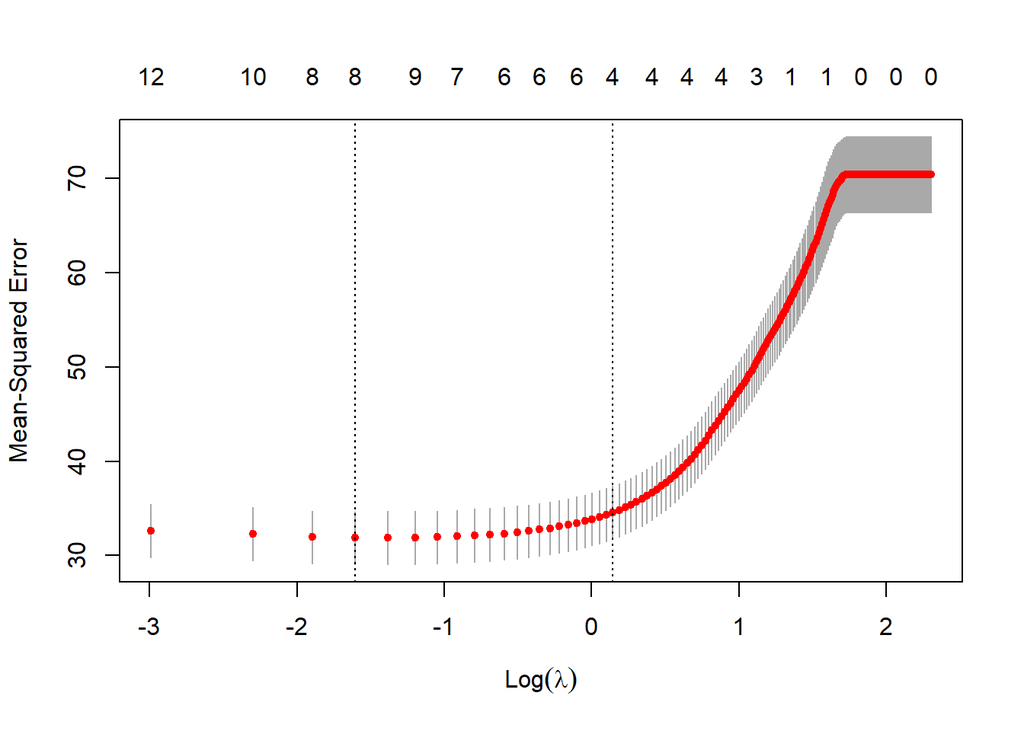

```r
cv_lasso_fit %>% plot
```

```r
cv_lasso_fit %>% coef
```

```
## 17 x 1 sparse Matrix of class "dgCMatrix"
##                            1
## (Intercept)     17.919686556
## NBA_DraftNumber -0.080381345
## Age              0.300774816
## MP               0.003422173
## PER              .
## TS%              .
## DRB%             .
## VORP             .
## G                .
## OBPM             .
## DBPM             .
## BPM              .
## OWS              .
## DWS              .
## WS               0.286224087
## AST%             .
## STL%             .
```

0인거 보이지?

```r
lasso_fit = glmnet(x = train_x, y = train_y, alpha = 1, lambda = opt_ridge_lambda)
lasso_fit %>% coef
```

```
## 17 x 1 sparse Matrix of class "dgCMatrix"
##                           s0
## (Intercept)     15.629200258
## NBA_DraftNumber -0.094814213
## Age              0.393897508
## MP               0.003562858
## PER              .
## TS%              .
## DRB%             .
## VORP             0.148532971
## G                .
## OBPM             .
## DBPM             .
## BPM              .
## OWS              .
## DWS              0.106149046
## WS               0.245335936
## AST%             .
## STL%             .
```

### **결과 비교!!!!**

```r
pred_bs_y = predict(best_lm_fit, test)
pred_pcr_y = predict(pcr_fit, test)
pred_ridge_y = predict(ridge_fit, s = opt_ridge_lambda, newx = test_x)
pred_lasso_y = predict(lasso_fit, s = opt_lasso_lambda, newx = test_x)
```

각각 예측값 저장하고,

```r
RMSE(pred_bs_y, test_y)
```

```
## [1] 5.995564
```

```r
RMSE(pred_pcr_y, test_y)
```

```
## [1] 6.691174
```

```r
RMSE(pred_ridge_y, test_y)
```

```
## [1] 6.006457
```

```r
RMSE(pred_lasso_y, test_y)
```

```
## [1] 6.104631
```

결과가 이렇다!